# Clustering of all samples

Data quality assessment and quality control (i.e. the removal of insufficiently good data) are essential steps of any data analysis. These steps should typically be performed very early in the analysis of a new data set, preceding or in parallel to the differential expression testing.

We define the term quality as fitness for purpose. Our purpose is the detection of differentially expressed genes, and we are looking in particular for samples whose experimental treatment suffered from an anormality that renders the data points obtained from these particular samples detrimental to our purpose.

In this page, you will see all of the analysis performed to understand which samples are potentially going to negatively impact the downstream analysis.

# Set up the DESeq2 object

# Return the results

```r
res <- results(dds, contrast = c("disease", "GDM", "Normal"))

res[order(res$padj),] %>%  head
```

```
## log2 fold change (MLE): disease GDM vs Normal
## Wald test p-value: disease GDM vs Normal
## DataFrame with 6 rows and 6 columns
##                  baseMean log2FoldChange     lfcSE      stat      pvalue
##                 <numeric>      <numeric> <numeric> <numeric>   <numeric>
## ENSG00000158578   112.042      -2.288636  0.429711  -5.32599 1.00406e-07
## ENSG00000164308   194.925      -1.443959  0.297473  -4.85409 1.20943e-06
## ENSG00000206172  3619.493      -1.486767  0.305291  -4.86999 1.11602e-06
## ENSG00000034510   529.142      -0.989171  0.213005  -4.64389 3.41910e-06
## ENSG00000111229  1552.599      -0.637570  0.135748  -4.69672 2.64366e-06
## ENSG00000112787   377.714       0.913416  0.198051   4.61203 3.98764e-06
##                       padj
##                  <numeric>
## ENSG00000158578 0.00124252
## ENSG00000164308 0.00498891
## ENSG00000206172 0.00498891
## ENSG00000034510 0.00659541
## ENSG00000111229 0.00659541
## ENSG00000112787 0.00659541
```

```r
res_df <- data.frame(res[order(res$padj),])
```

# Heatmap of counts matrix

To explore a count matrix, it is often instructive to look at it as a heatmap. Below we show how to produce such a heatmap for various transformations of the data. I have plotted a heatmap of the top 200 highly expressed genes to determine if the samples cluster together by condition.

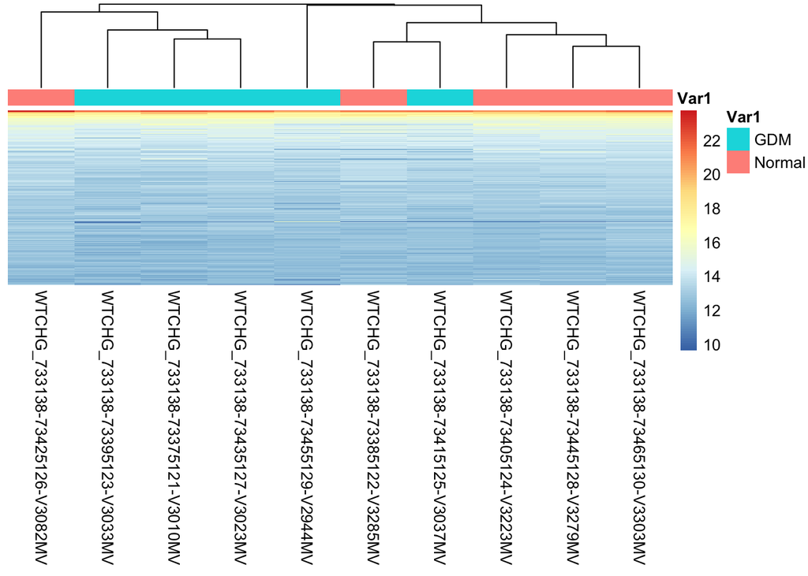

# Explore the histogram of p-values

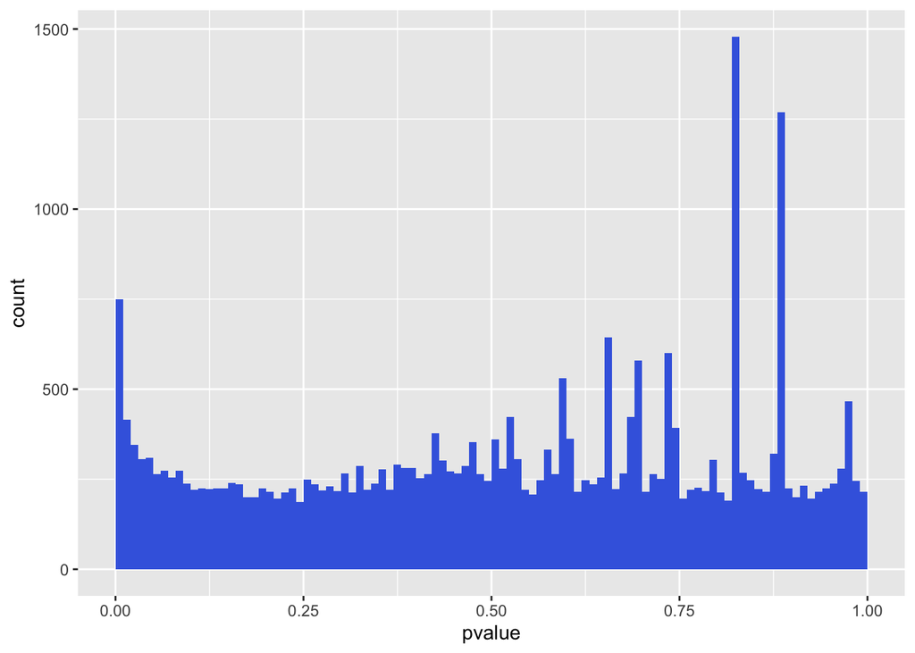

```r
ggplot(res_df, aes(x = pvalue)) +
  geom_histogram(binwidth = 0.01, fill = "Royalblue", boundary = 0)
```

# Heatmap of sample-to-sample distances

Another use of the transformed data is sample clustering. Here, we apply the dist function to the transpose of the transformed count matrix to get sample-to-sample distances.

A heatmap of this distance matrix gives us an overview over similarities and dissimilarities between samples. We have to provide a hierarchical clustering hc to the heatmap function based on the sample distances, or else the heatmap function would calculate a clustering based on the distances between the rows/columns of the distance matrix.

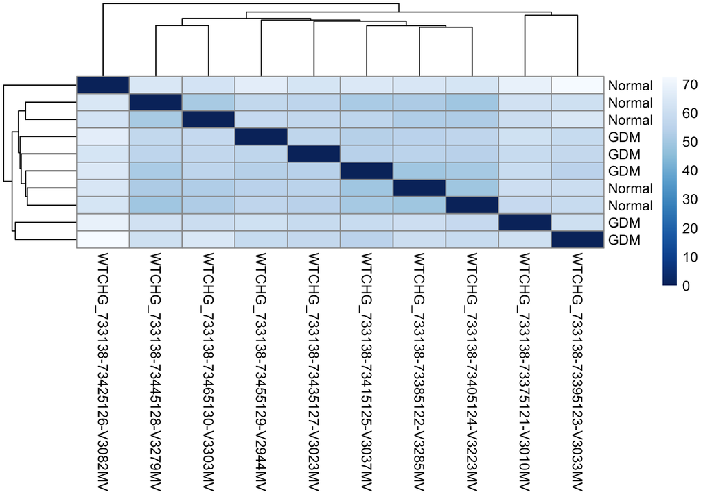

# PCA analysis of the samples

Related to the distance matrix is the PCA plot, which shows the samples in the 2D plane spanned by their first two principal components. This type of plot is useful for visualizing the overall effect of experimental covariates and batch effects.

## PCA - group

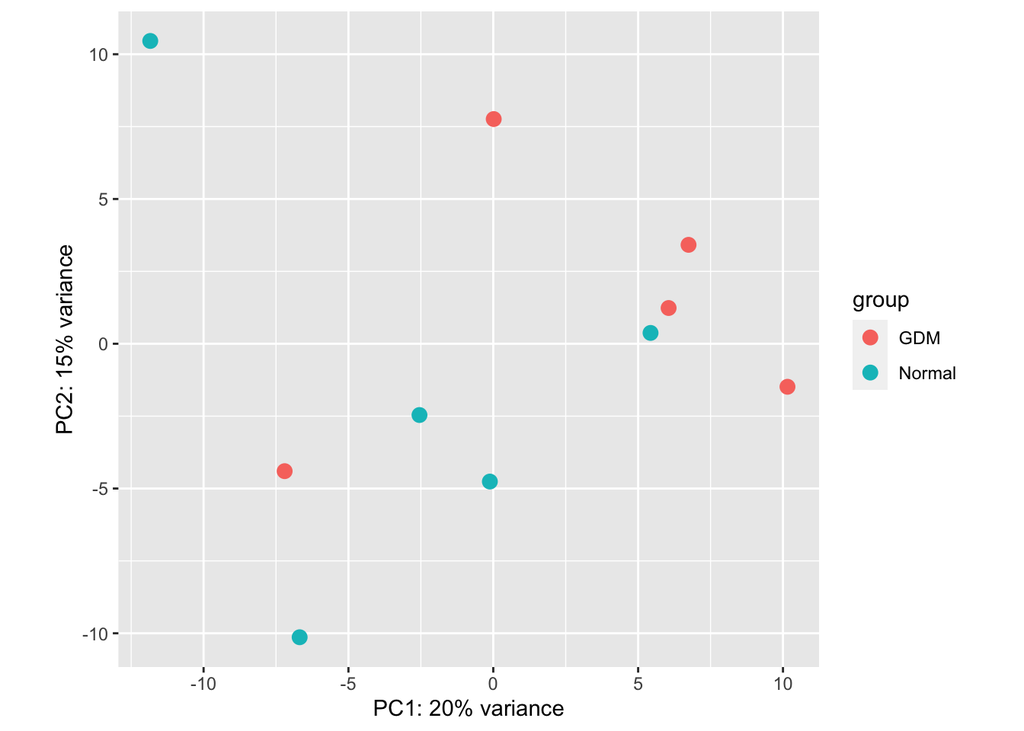

## MA plots

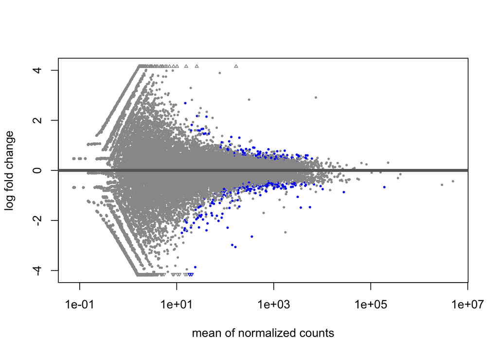